# 客户流失预警分析

葛宇泽 19307130176

2021/10/22

### 1.读入训练数据

```r
setwd("F:\\2021秋季\\机器学习\\HW4")
data = read.csv("sampledata.csv",header=T,fileEncoding = "UTF-8")
```

整理得到如下

```r
library(knitr)
kable(summary(data))
```

|  | ID | tenure | expense | degree | tightness | entropy | chgexpense | chgdegree | churn |
| --- | --- | --- | --- | --- | --- | --- | --- | --- | --- |
|  | Min. : 1 | Min. : 184.0 | Min. : 0.1784 | Min. : 0.04722 | Min. : 0.00486 | Min. :0.000 | Min. :-1.00000 | Min. :-0.9964 | Min. :0.00000 |
|  | 1st Qu.:12096 | 1st Qu.: 537.1 | 1st Qu.: 98.2789 | 1st Qu.: 30.34109 | 1st Qu.: 5.41880 | 1st Qu.:2.373 | 1st Qu.:-0.07634 | 1st Qu.:-0.1573 | 1st Qu.:0.00000 |
|  | Median :24201 | Median : 994.7 | Median :136.0573 | Median : 54.12898 | Median : 8.03004 | Median :2.990 | Median : 0.00000 | Median : 0.0000 | Median :0.00000 |
|  | Mean :24198 | Mean :1257.5 | Mean :161.2421 | Mean : 66.68942 | Mean : 9.86537 | Mean :2.931 | Mean : 0.00762 | Mean : 0.0376 | Mean :0.01247 |
|  | 3rd Qu.:36299 | 3rd Qu.:1635.9 | 3rd Qu.:204.0966 | 3rd Qu.: 89.85727 | 3rd Qu.:11.94831 | 3rd Qu.:3.559 | 3rd Qu.: 0.04337 | 3rd Qu.: 0.1667 | 3rd Qu.:0.00000 |
|  | Max. :48393 | Max. :4479.6 | Max. :511.0550 | Max. :303.98270 | Max. :61.67615 | Max. :5.346 | Max. : 2.66502 | Max. : 7.3333 | Max. :1.00000 |

### 2.绘制因变量和各个自变量的箱线图

首先绘制各自变量与因变量的箱线图(中位数用横线表示,均值用点表示)

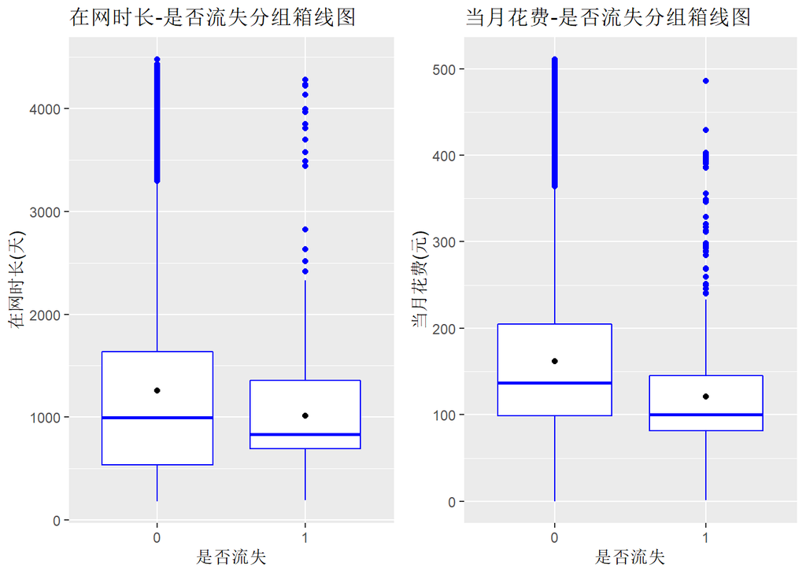

```r
library(ggplot2)
library(Rmisc)
p1 = ggplot(data=data, aes(x=factor(churn), y=tenure,gruop=2)) + geom_boxplot(col="blue") + labs(title="在网时长-是否流失分组箱线图",x="是否流失", y = "在网时长(天)")+stat_summary(fun="mean", geom="point")
p2 = ggplot(data=data, aes(x=factor(churn), y=expense,gruop=2)) + geom_boxplot(col="blue") + labs(title="当月花费-是否流失分组箱线图",x="是否流失", y = "当月花费(元)")+stat_summary(fun="mean", geom="point")
p3 = ggplot(data=data, aes(x=factor(churn), y=degree,gruop=2)) + geom_boxplot(col="blue") + labs(title="个体的度-是否流失分组箱线图",x="是否流失", y = "个体的度(人)")+stat_summary(fun="mean", geom="point")
p4 = ggplot(data=data, aes(x=factor(churn), y=tightness,gruop=2)) + geom_boxplot(col="blue") + labs(title="联系强度-是否流失分组箱线图",x="是否流失", y = "联系强度(分钟/人")+stat_summary(fun="mean", geom="point")
p5 = ggplot(data=data, aes(x=factor(churn), y=entropy,gruop=2)) + geom_boxplot(col="blue") + labs(title="个体信息熵-是否流失分组箱线图",x="是否流失", y = "个体信息熵")+stat_summary(fun="mean", geom="point")
p6 = ggplot(data=data, aes(x=factor(churn), y=chgdegree,gruop=2)) + geom_boxplot(col="blue") + labs(title="个体度的变化-是否流失分组箱线图",x="是否流失", y = "个体度的变化(%)")+stat_summary(fun="mean", geom="point")
p7 = ggplot(data=data, aes(x=factor(churn), y=chgexpense,gruop=2)) + geom_boxplot(col="blue") + labs(title="花费的变化-是否流失分组箱线图",x="是否流失", y = "花费的变化(%)")+stat_summary(fun="mean", geom="point")
#图中点表示均值
multiplot(p1,p2,cols=2)
```

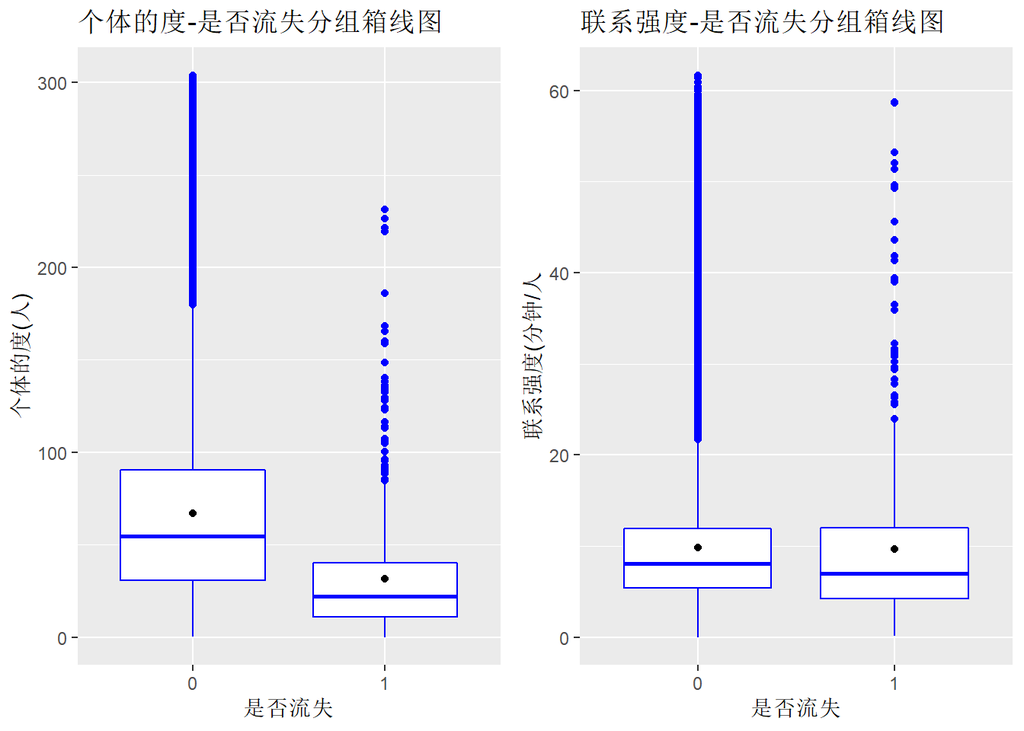

```r
multiplot(p3,p4,cols=2)
```

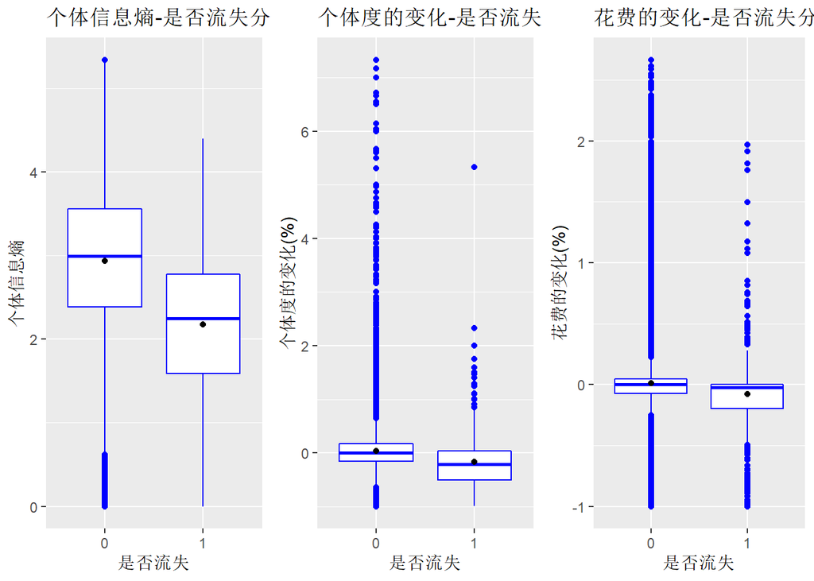

```r
multiplot(p5,p6,p7,cols=3)
```

从图中可以大致看出，用户在网时间越长、当月花费越多、个体度越高、个体信息熵越大、个体度负向变化越小、花费负向变化越小，流失的可能性越低。是否流失在联系强度上差异不明显。

另外,在网时长、当月花费、个体的度、联系强度数据有比较明显的右偏分布。对上述数据取对数后作出箱线图。

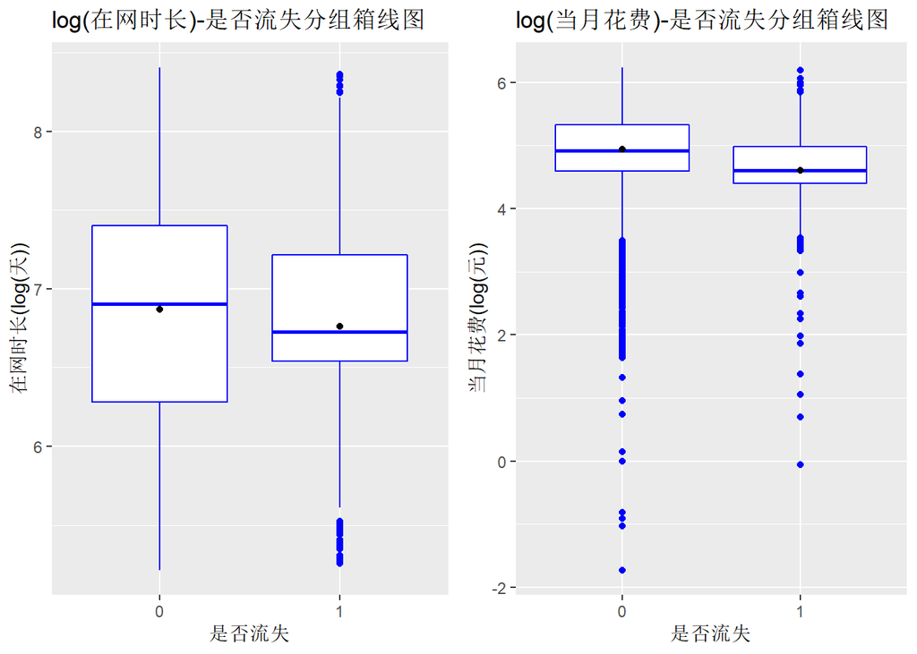

```r
p1 = ggplot(data=data, aes(x=factor(churn), y=log(tenure),gruop=2)) + geom_boxplot(col="blue") + labs(title="log(在网时长)-是否流失分组箱线图",x="是否流失", y = "在网时长(log(天))")+stat_summary(fun="mean", geom="point")
p2 = ggplot(data=data, aes(x=factor(churn), y=log(expense),gruop=2)) + geom_boxplot(col="blue") + labs(title="log(当月花费)-是否流失分组箱线图",x="是否流失", y = "当月花费(log(元))")+stat_summary(fun="mean", geom="point")
p3 = ggplot(data=data, aes(x=factor(churn), y=log(degree),gruop=2)) + geom_boxplot(col="blue") + labs(title="log(个体的度)-是否流失分组箱线图",x="是否流失", y = "个体的度(log(人))")+stat_summary(fun="mean", geom="point")
p4 = ggplot(data=data, aes(x=factor(churn), y=log(tightness),gruop=2)) + geom_boxplot(col="blue") + labs(title="log(联系强度)-是否流失分组箱线图",x="是否流失", y = "联系强度(log(分钟/人))")+stat_summary(fun="mean", geom="point")
multiplot(p1,p2,cols = 2)
```

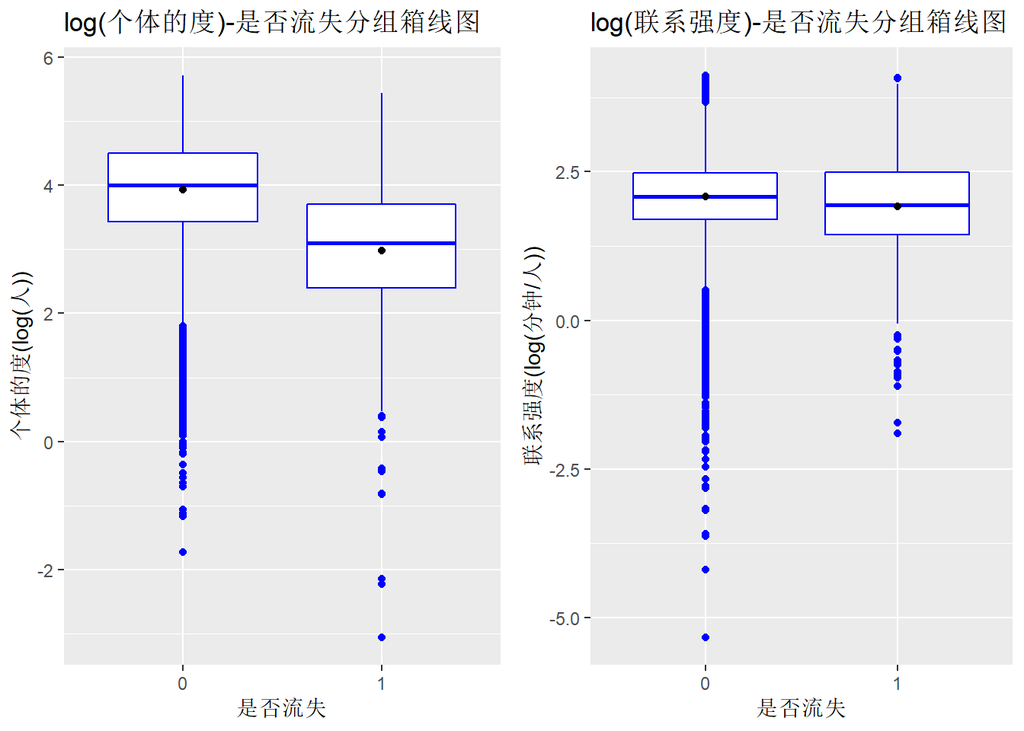

```r
multiplot(p3,p4,cols = 2)
```

取对数后，偏态分布得到改善

### 3.以是否流失为因变量，对自变量进行标准化,建立逻辑回归模型,给出系数估计结果,并对结果进行解读

```r
#标准化数据
data2 = data
data2$tenure = scale(data2$tenure)
data2$expense = scale(data2$expense)
data2$degree = scale(data2$degree)
data2$tightness = scale(data2$tightness)
data2$entropy = scale(data2$entropy)
data2$chgexpense = scale(data2$chgexpense)
data2$chgdegree = scale(data2$chgdegree)

#建立模型
model <- glm(churn ~ tenure + expense + degree  + entropy + tightness + chgdegree + chgexpense, family = "binomial"(link=logit), data = data2)
summary(model)
```

```
##
## Call:
## glm(formula = churn ~ tenure + expense + degree + entropy + tightness +
##     chgdegree + chgexpense, family = binomial(link = logit),
##     data = data2)
##
## Deviance Residuals:
##     Min       1Q   Median       3Q      Max
## -0.8909  -0.1748  -0.1198  -0.0748   4.2072
##
## Coefficients:
##             Estimate Std. Error z value Pr(>|z|)
## (Intercept) -5.05338    0.07212 -70.067  < 2e-16 ***
## tenure      -0.24767    0.06070  -4.080 4.50e-05 ***
## expense     -0.29229    0.05904  -4.951 7.39e-07 ***
## degree      -0.73751    0.13172  -5.599 2.15e-08 ***
## entropy     -0.35176    0.07208  -4.880 1.06e-06 ***
## tightness   -0.22660    0.04254  -5.327 9.99e-08 ***
## chgdegree   -0.38279    0.05208  -7.349 1.99e-13 ***
## chgexpense  -0.16071    0.04893  -3.284  0.00102 **
## ---
## Signif. codes:  0 '***' 0.001 '**' 0.01 '*' 0.05 '.' 0.1 ' ' 1
##
## (Dispersion parameter for binomial family taken to be 1)
##
##     Null deviance: 6475.5  on 48284  degrees of freedom
## Residual deviance: 5757.6  on 48277  degrees of freedom
## AIC: 5773.6
##
## Number of Fisher Scoring iterations: 8
```

回归结果如下

|  | 估计值 | 标准误差 | P值 |
| --- | --- | --- | --- |
| Intercept | -5.053 | 0.072 | 0.000 |
| degree | -0.738 | 0.132 | 0.000 |
| chgdegree | -0.383 | 0.052 | 0.000 |
| entropy | -0.352 | 0.072 | 0.000 |
| expense | -0.292 | 0.059 | 0.000 |
| tenure | -0.248 | 0.061 | 0.000 |
| tightness | -0.227 | 0.043 | 0.000 |
| chgexpense | -0.161 | 0.049 | 0.001 |

回归结果显示，各自变量的P值均很小，说明是显著的。

由公式$P(Y=1|X=x)=\frac{exp(x^\top \beta)}{1+exp(x^\top \beta)}$,且回归系数均小于0可知：x越大，流失的可能性越低。即用户在网时长、月花费、用户的度、用户联系强度、用户信息熵越大，个体度与花费正向变化越大，用户流失的可能性越低。

由上述公式可知，回归系数绝对值越大，相应x每增加一个单位，大体上概率的改变量就越大(二者并非线性关系)。回归系数绝对值从大到小分别是：个体的度、个体度的改变、个体信息熵、当月花费、在网时长、联系强度、花费的变化。它们对流失概率影响的大小也是这个顺序。

### 4.使用建立好的逻辑回归模型，分别对训练集和测试集进行预测，得到每个用户的预测流失概率值

```r
#读入测试集数据
data_pred = read.csv("preddata.csv",header=T,fileEncoding = "UTF-8")

#标准化测试集数据
data_pred$tenure = scale(data_pred$tenure)
data_pred$expense = scale(data_pred$expense)
data_pred$degree = scale(data_pred$degree)
data_pred$tightness = scale(data_pred$tightness)
data_pred$entropy = scale(data_pred$entropy)
data_pred$chgexpense = scale(data_pred$chgexpense)
data_pred$chgdegree = scale(data_pred$chgdegree)

#进行预测
library(pROC)
pred_sample = predict(model,data2,type = 'response')
pred_test = predict(model,data_pred,type = 'response')
```

得到训练集预测概率如下

```r
summary(pred_sample)
```

```
##      Min.   1st Qu.    Median      Mean   3rd Qu.      Max.
## 0.0000002 0.0029470 0.0073930 0.0124676 0.0155745 0.3513684
```

得到测试集预测概率如下

```r
summary(pred_test)
```

```
##      Min.   1st Qu.    Median      Mean   3rd Qu.      Max.
## 0.0000018 0.0029631 0.0073703 0.0125370 0.0154479 0.3551990
```

### 5.借助问题4中预测的结果，分别绘制训练集和测试集上预测结果的ROC曲线，计算相应的AUC值，并根据ROC曲线和AUC值对模型进行评价

对训练集结果绘制ROC曲线并计算出AUC

```r
roc_sample = roc(data2$churn,pred_sample)
```

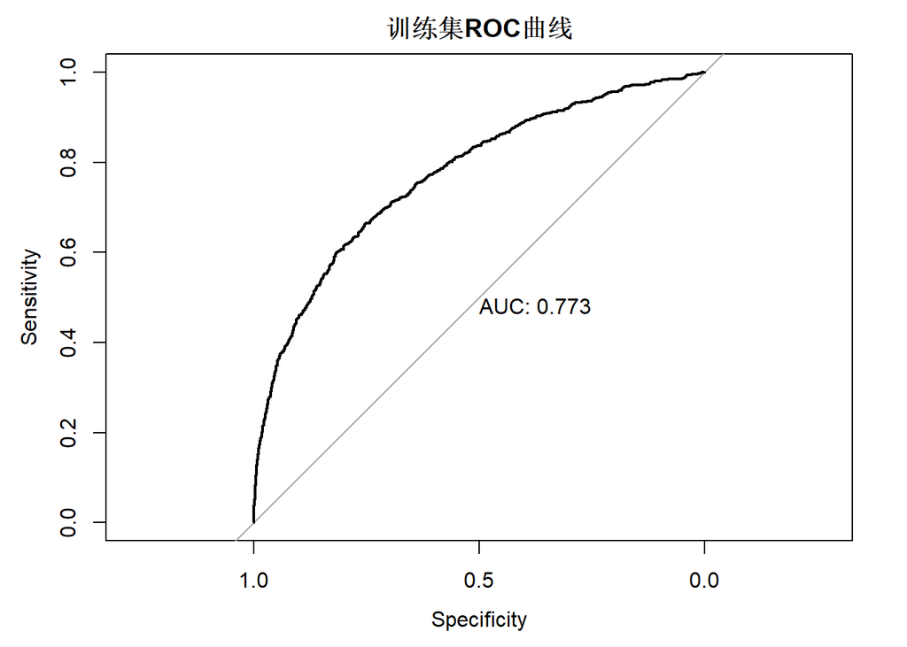

```r
plot(roc_sample,print.auc = T,main='训练集ROC曲线')
```

对测试集结果绘制ROC曲线

```r
roc_test = roc(data_pred$churn,pred_test)
```

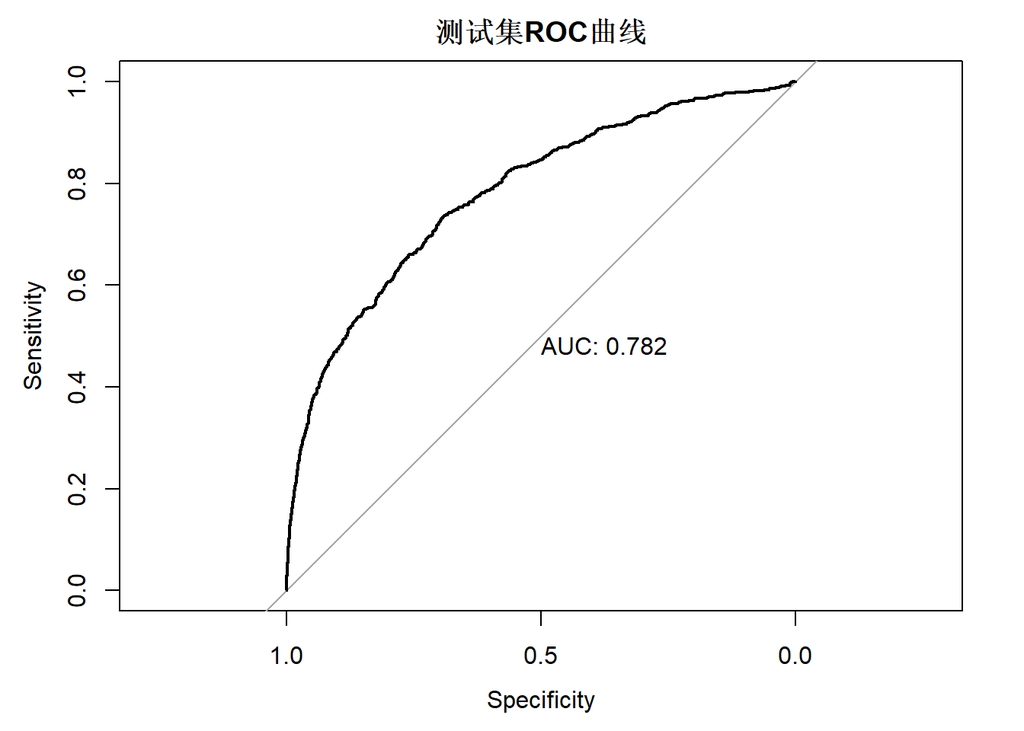

```r
plot(roc_test,print.auc = T,main='测试集ROC曲线')
```

训练集ROC曲线的AUC为0.773，测试集ROC曲线的AUC为0.782。二者均大于0.5且较大，而且二者大小相近。这说明模型有较好的预测效果，且不存在过拟合问题，有较好的泛化能力。